# Ovarian_dataset

Alexandra Tsitrina

2/28/2021

## Анализ выживаемости

Необходимые библиотеки

```r
options(encoding = "UTF-8")

PkgNames <- c("survival", "survminer", "dplyr", "ggplot2", "utf8", "caTools", "lubridate",
    "gtsummary")
new.packages <- PkgNames[!(PkgNames %in% installed.packages()[, "Package"])]
if (length(new.packages)) install.packages(new.packages)

invisible(suppressMessages(suppressWarnings(lapply(PkgNames, require, character.only = T))))
```

## Данные

Загрузим данные и посмотрим на их структуру. Значения переменных: futime: survival or censoring time fustat: censoring status age: in years resid.ds: residual disease present (1=no,2=yes) rx: treatment group ecog.ps: ECOG performance status (1 is better, see reference)

Проведем EDA нашего датасета. Переведем переменные resid.ds, rx, ecog.ps в факторный вид. Построим гистограмму распределения испытуюмых по возрасту, как видно из данных гистограммы, 55 лет является средним возрастом по нашей выборке. Поэтому, создадим новую факторную переменную, обозначающую возраст - старше 55 лет или моложе 55 (over_55).

```
## 'data.frame':    26 obs. of  6 variables:
##  $ futime  : num  59 115 156 421 431 448 464 475 477 563 ...
##  $ fustat  : num  1 1 1 0 1 0 1 1 0 1 ...
##  $ age     : num  72.3 74.5 66.5 53.4 50.3 ...
##  $ resid.ds: num  2 2 2 2 2 1 2 2 2 1 ...
##  $ rx      : num  1 1 1 2 1 1 2 2 1 2 ...
##  $ ecog.ps : num  1 1 2 1 1 2 2 2 1 2 ...
```

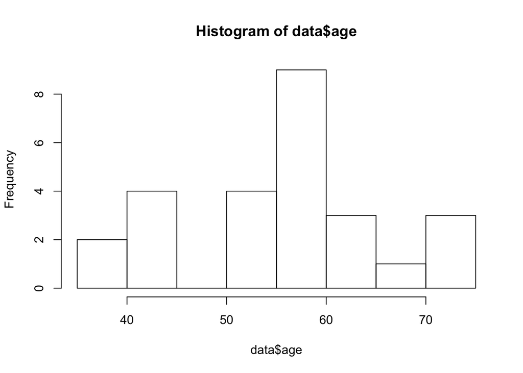

## Кривые Каплана Майера

Построим кривые выживаемости Каплана-Майера в зависимости от факторных переменных. Как видно из графиков, значимо (p<0.05) на выживаемость влияет только возраст пациента (старше или моложе 55 лет). Стоит заметить, что переменная resid.ds также значительно, хоть и не достоверно, влияет на выживаемость пациентов (p = 0.057).

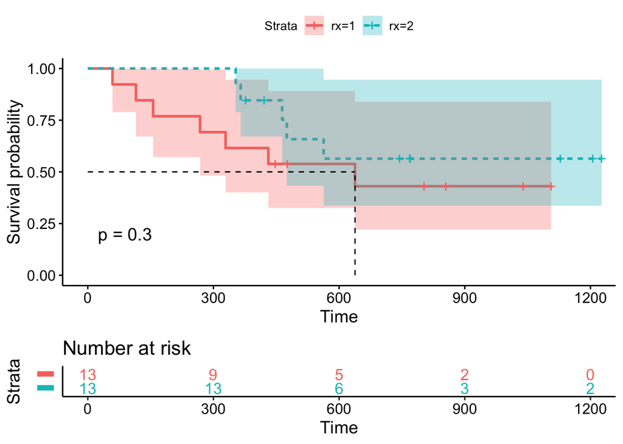

```r
surv_object <- Surv(time = data$futime, event = data$fustat)
fit <- survfit(surv_object ~ rx, data = ovarian)
ggsurvplot(fit, data = ovarian, pval = TRUE, conf.int = TRUE, risk.table = TRUE,
    risk.table.col = "strata", linetype = "strata", surv.median.line = "hv", risk.table.y.text = FALSE)
```

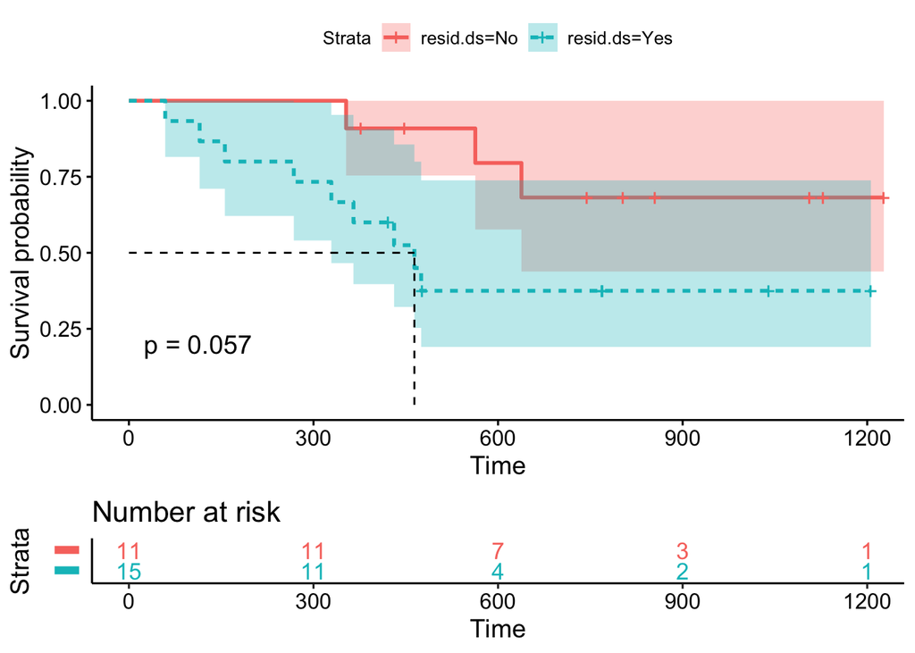

```r
fit1 <- survfit(surv_object ~ resid.ds, data = data)
fit2 <- survfit(surv_object ~ ecog.ps, data = data)
ggsurvplot(fit1, data = data, pval = TRUE, conf.int = TRUE, risk.table = TRUE, risk.table.col = "strata",
    linetype = "strata", surv.median.line = "hv", risk.table.y.text = FALSE)
```

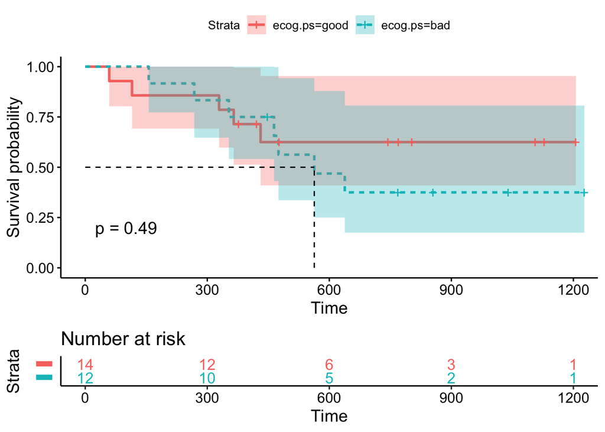

```r
ggsurvplot(fit2, data = data, pval = TRUE, conf.int = TRUE, risk.table = TRUE, risk.table.col = "strata",
    linetype = "strata", surv.median.line = "hv", risk.table.y.text = FALSE)
```

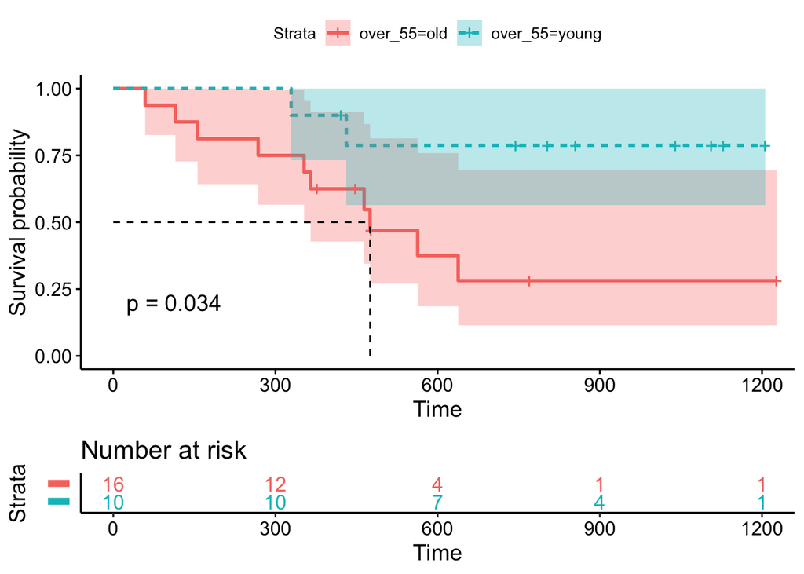

```r
fit3 <- survfit(surv_object ~ over_55, data)
ggsurvplot(fit3, data = data, pval = TRUE, conf.int = TRUE, risk.table = TRUE, risk.table.col = "strata",
    linetype = "strata", surv.median.line = "hv", risk.table.y.text = FALSE)
```

```r
summary(fit3)
```

```
## Call: survfit(formula = surv_object ~ over_55, data = data)
##
##                 over_55=old
##  time n.risk n.event survival std.err lower 95% CI upper 95% CI
##    59     16       1    0.938  0.0605        0.826        1.000
##   115     15       1    0.875  0.0827        0.727        1.000
##   156     14       1    0.812  0.0976        0.642        1.000
##   268     13       1    0.750  0.1083        0.565        0.995
##   353     12       1    0.688  0.1159        0.494        0.957
##   365     11       1    0.625  0.1210        0.428        0.914
##   464      8       1    0.547  0.1287        0.345        0.867
##   475      7       1    0.469  0.1319        0.270        0.814
##   563      5       1    0.375  0.1348        0.185        0.758
##   638      4       1    0.281  0.1296        0.114        0.694
##
##                 over_55=young
##  time n.risk n.event survival std.err lower 95% CI upper 95% CI
##   329     10       1    0.900  0.0949        0.732            1
##   431      8       1    0.787  0.1340        0.564            1
```

## Сравнение групп при помощи log-rank теста

Используем log-rank тест для оценки различий между 2-мя кривыми выживаемости для кривых, построенных для возраста (over_55) и наличия остаточного заболевания (resid.ds). Согласно результатам теста, возраст (больше или меньше 55 лет) значимо влияет на вероятность выжить (p=0.03). Наличие остаточного заболевания также вносит весомый вклад в вероятность выжить, несмотря на то, что p = 0.06. В данном случае,мы не можем сказать, что это влияние достоверно (т.к. мы отвергаем H0 при p < 0.05). Такой результат может объясняться небольшой выборкой, возможно, имей мы больше наблюдений, переменная resid.ds также оказывала бы значимое влияние на выживаемость.

```r
surv_diff_age <- survdiff(Surv(time = data$futime, event = data$fustat) ~ over_55,
    data)
surv_diff_age
```

```
## Call:
## survdiff(formula = Surv(time = data$futime, event = data$fustat) ~
##     over_55, data = data)
##
##                N Observed Expected (O-E)^2/E (O-E)^2/V
## over_55=old   16       10     6.37      2.06      4.49
## over_55=young 10        2     5.63      2.34      4.49
##
##  Chisq= 4.5  on 1 degrees of freedom, p= 0.03
```

```r
surv_diff_resid <- survdiff(Surv(time = data$futime, event = data$fustat) ~ resid.ds,
    data = data)
surv_diff_resid
```

```
## Call:
## survdiff(formula = Surv(time = data$futime, event = data$fustat) ~
##     resid.ds, data = data)
##
##               N Observed Expected (O-E)^2/E (O-E)^2/V
## resid.ds=No  11        3     6.26      1.70      3.62
## resid.ds=Yes 15        9     5.74      1.85      3.62
##
##  Chisq= 3.6  on 1 degrees of freedom, p= 0.06
```

## Анализ факторов, влияющих на риск (модель Кокса)

Т.к. модель Кокса может работать как с факторными, так и с нумерическими данными, для начала построим модель, учитывающую реальный возраст (age) пациента. Как видно из данных таблицы и графика отношения рисков, при такой модели, только реальный возраст оказывает влияние на шансы пациента на выживание (p = 0.008). При увеличении возраста, шансы выжить падают.

```r
fit.coxph <- coxph(surv_object ~ rx + resid.ds + age + ecog.ps, data = data)
fit.coxph %>% tbl_regression(exp = TRUE)
```

| **Characteristic** | **HR**<sup>1</sup> | **95% CI**<sup>1</sup> | **p-value** |
| --- | --- | --- | --- |
| rx |  |  |  |
| A | — | — |  |
| B | 0.40 | 0.11, 1.44 | 0.2 |
| resid.ds |  |  |  |
| No | — | — |  |
| Yes | 2.28 | 0.49, 10.7 | 0.3 |
| age | 1.13 | 1.03, 1.24 | 0.008 |
| ecog.ps |  |  |  |
| good | — | — |  |
| bad | 1.40 | 0.40, 4.94 | 0.6 |

<sup>*1*</sup> HR = Hazard Ratio, CI = Confidence Interval

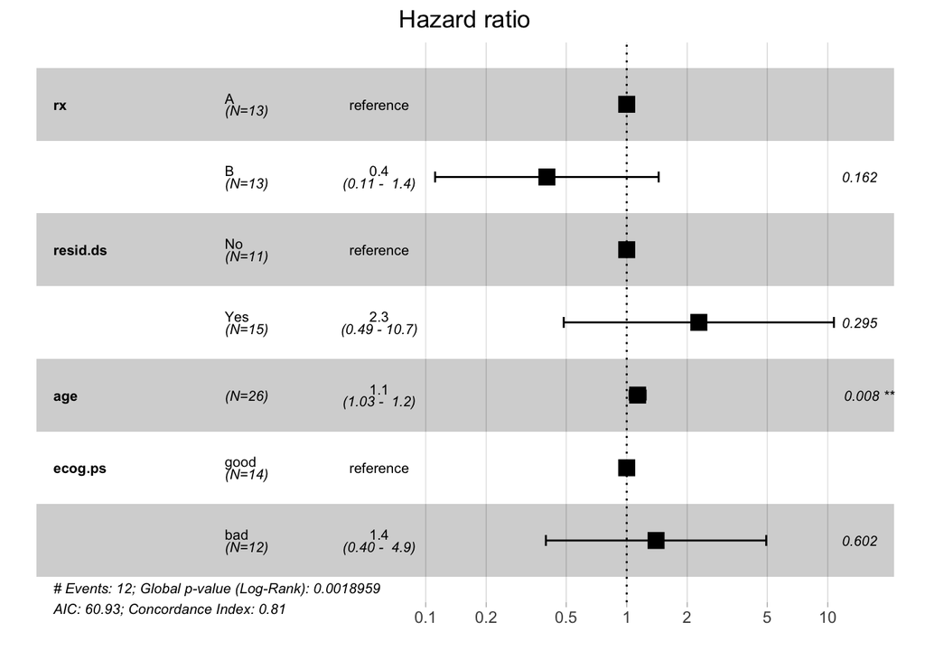

```r
ggforest(fit.coxph, data = data)
```

Построим другую модель Кокса, учитывающую возраст как факторную величину (over_55). В такой модели, тип лечения (rx) B значительно увеличивает шансы выжить для пациента (p = 0.047). Возраст меньше 55 лет, также достоверно увеличивает шансы на выживание в этой модели (p=0.033). Наличие остаточного заболевания опять же недостоверно (p=0.069) снижает шансы пациента на выживание.

```r
fit.coxph1 <- coxph(surv_object ~ rx + resid.ds + over_55 + ecog.ps, data = data)
fit.coxph1 %>% tbl_regression(exp = TRUE)
```

| **Characteristic** | **HR**<sup>1</sup> | **95% CI**<sup>1</sup> | **p-value** |
| --- | --- | --- | --- |
| rx |  |  |  |
| A | — | — |  |
| B | 0.28 | 0.08, 0.99 | 0.047 |
| resid.ds |  |  |  |
| No | — | — |  |
| Yes | 3.79 | 0.90, 15.9 | 0.069 |
| over_55 |  |  |  |
| old | — | — |  |
| young | 0.17 | 0.04, 0.87 | 0.033 |
| ecog.ps |  |  |  |
| good | — | — |  |
| bad | 1.23 | 0.36, 4.25 | 0.7 |

<sup>*1*</sup> HR = Hazard Ratio, CI = Confidence Interval

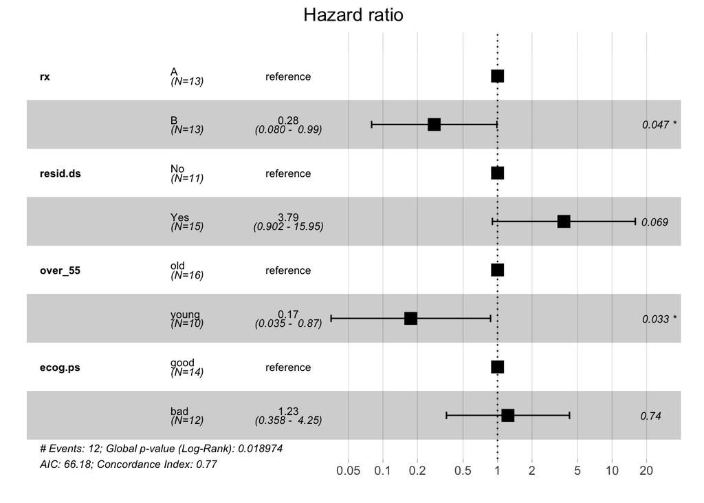

```r
ggforest(fit.coxph1, data = data)
```

## Выводы

Согласно проведенному анализу можно сказать, что выживаемость пациентов с раком яичников зависит в первую очередь от возраста пациентов. Чем старше пациент, тем меньше для него вероятность выжить. Также, согласно модели Кокса, тип лечения B увеличивает шансы выжить для пациентов, однако этот вывод не подтверждается другими моделями. Наличие остаточного заболевания (resid.ds) хоть и не оказывает достоверного влияния на выживаемость в нашей выборке, при увеличении количества участников исследования может перейти в категорию значимых предикторов и снижать шансы на выживание.